# Лабораторная работа №5

Презентация

Устинова В. В.

Российский университет дружбы народов, Москва, Россия

18 апреля 2026

# Информация

## Докладчик

- Устинова Виктория Вадимовна
- студент НПИбд-01-24
- Российский университет дружбы народов

## Цель работы

Изучение механизмов изменения идентификаторов, применения SetUID- и Sticky-битов. Получение практических навыков работы в консоли с дополнительными атрибутами. Рассмотрение работы механизма смены идентификатора процессов пользователей, а также влияние бита Sticky на запись и удаление файлов.

## Задание

Выполнить порядок выполнения работы 1. Создание программы 2. Исследование Sticky-бита

## Создание программы

Войдите в систему от имени пользователя guest, создайте программу simpleid.c, скомплилируйте программу, выполните программу simpleid, выполните системную программу id:

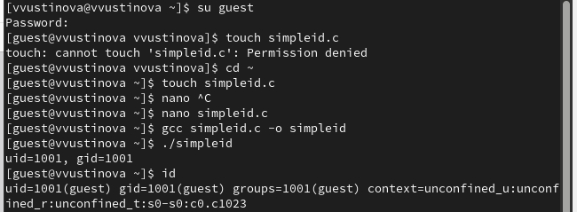

Выполняем задания

## Создание программы

Создайте simpleid2.с, Скомпилируйте и запустите simpleid2.c, выполните проверку правильности установки новых атрибутов и смены владельца файла simpleid2, запустите simpleid2 и id:

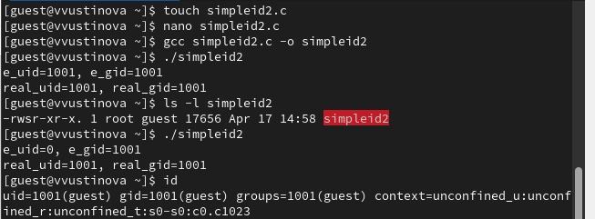

Создаем файл и вставляем текст

## Создание программы

От имени суперпользователя выполните команды:(

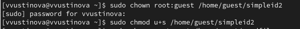

Вводим следующие команды

## Создание программы

Создайте программу readfile.c, откомпилируйте её,проверьте, может ли программа readfile прочитать файл readfile.с, Проверьте, может ли программа readfile прочитать файл /etc/shadow

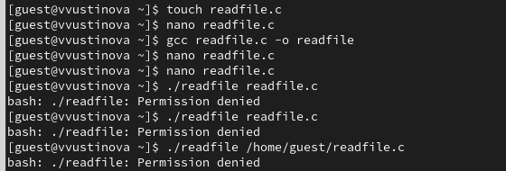

## Создание программы

Смените владельца у файла readfile.c (или любого другого текстового файла в системе) и измените права так, чтобы только суперпользователь (root) мог прочитать его, a guest не мог

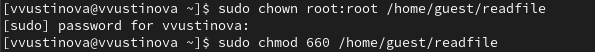

вводим команду

## Исследование Sticky-бита

От имени пользователя guest создайте файл file01.txt в директории /tmp со словом test,просмотрите атрибуты у только что созданного файла и разрешите чтение и запись для категории пользователей «все остальные»

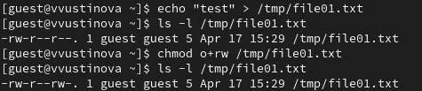

Вводим команды из туиса

## Исследование Sticky-бита

От пользователя guest2 (не являющегося владельцем) попробуйте прочитать файл /tmp/file01.txt,От пользователя guest2 попробуйте дозаписать в файл /tmp/file01.txt слово test2 командой

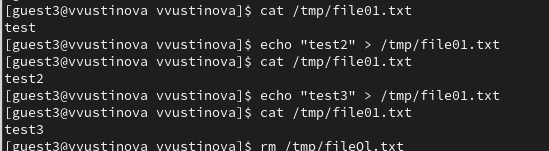

Мне удалось это сделать я проверила командой cat

## Исследование Sticky-бита

От пользователя guest2 попробуйте удалить файл /tmp/file01.txt командой,повысьте свои права до суперпользователя следующей командой

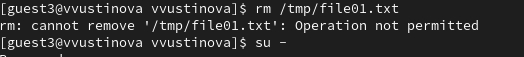

Не удалось удалить файл

## Исследование Sticky-бита

Выполните после этого команду, снимающую атрибут t (Sticky-бит) с директории /tmp, покиньте режим суперпользователя командой

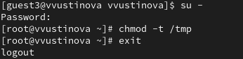

ВЫполянем команды из туиса

## Исследование Sticky-бита

От пользователя guest2 проверьте, что атрибута t у директории /tmp нет, повторите предыдущие шаги

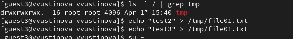

## Исследование Sticky-бита

Повысьте свои права до суперпользователя и верните атрибут t на директорию /tmp

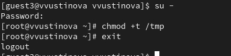

Выполняем задания

## Выводы

У нас получилось изучить механизмы изменения идентификаторов, применения SetUID- и Sticky-битов. Получить практические навыки работы в консоли с дополнительными атрибутами. Рассмотреть работы механизма смены идентификатора процессов пользователей, а также влияние бита Sticky на запись и удаление файлов.